# Background: SPEI time series

S. Haire

4/29/2021

## Background: SPEI

The goal of this part of the project is to develop one or more metrics that represents environmental stress experienced by seedlings and young trees in openings resulting from severe fire. Standard Precipitation Evapotranspiration Index, or SPEI, is potentially useful for this purpose. SPEI is calculated as the difference between precipitation and potential evapotranspiration for each month. It is considered to be a good measure of drought severity in terms of intensity and duration and can identify the onset and end of drought episodes. The SPEI allows comparison of drought severity through time and space, since it can be calculated over a wide range of climates.

SPEI may better capture interactions of energy and water than other drought metrics. Such interactions can result in shifts in species distributions that do not correspond to expectations of upward or poleward movement. Furthermore, alternative climate metrics may enable better discernment of the influence of other factors on movement, such as life history traits or sensitivity to land use. In earlier explorations, SPEI showed signs of positive association with tree regeneration, based on ponderosa pine tree age data (internode counts).

SPEI offers long-time, robust information about drought conditions at the global scale, with a 0.5 degrees spatial resolution and a monthly time resolution. It has a multi-scale character, providing SPEI time-scales between 1 and 48 months. Currently it is available from January 1901 through December 2018. See: https://spei.csic.es/database.html https://climatedataguide.ucar.edu/climate-data/standardized-precipitation-evapotranspiration-index-spei

## Critical time periods for ponderosa pine germination and growth

We may be looking at the response of other tree species which have somewhat different requirements/limiting factors, but for now I’m focusing on ponderosa pine.

Germination. Germination and seedling establishment has been observed to begin in the spring farther north and after the monsoon in the south. To adequately capture conditions in these periods, I am looking at trends for 1) winter-spring (Feb-May) and 2) monsoon (July-October) across the study sites.

Growth. Ponderosa pine is generally drought-tolerant, but growth and survival are limited in years of extreme drought. Across all post-fire years, I am quantifying parameters to capture trends in extreme drought including 1) number of extreme events (downward spikes) and 2) length of prolonged periods of extreme drought (3 or more years ‘near’ the overall minimum value–tbd!).

## Site information

There were four unique fire years across the 13 sites: 2000, 2002, 2003, 2005. All were sampled in 2017 except Clear Creek (2018). Trend parameters were calculated based on the fire year–sampling data interval.

- 2000-2017 Hash Rock (Oregon), Outlet (Arizona), Cerro Grande (New Mexico), Pumpkin (Arizona)
- 2000-2018 Clear Creek Divide (Idaho)
- 2002-2017 747 Complex and Roberts Creek (Oregon), Hayman (Colorado), Missionary Ridge (Colorado), Ponil Complex (New Mexico), Rodeo (Arizona)
- 2003-2017 Poplar Complex (New Mexico)
- 2005-2017 Burnt Cabin (Oregon)

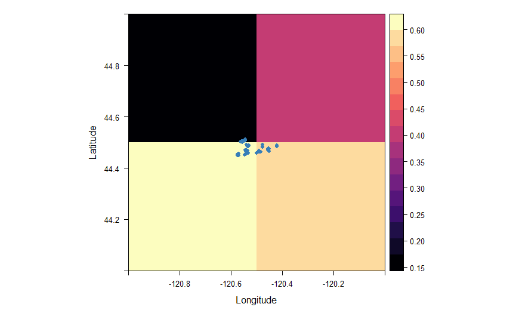

Most of sites fit into one climate data pixel–all except Hash Rock and Rodeo. The Hash Rock point locations (blue) are plotted on climate (SPEI) raster cells, above.